# Testovanie hypotéz v senzorike

Blok 2 · cvičenia 5a – 5d

Senzometria v R · SaIT

## Logika testu

- **H₀**: medzi vzorkami nie je rozdiel (hodnotitelia len hádajú)
- **H₁**: rozdiel existuje
- **p-hodnota**: aká pravdepodobná je pozorovaná (alebo extrémnejšia) situácia, ak platí H₀

p < 0,05 → zamietame H₀. Ale p ≥ 0,05 **neznamená**, že vzorky sú rovnaké – možno bol panel malý (blok 3).

## Ktorý test pre dve vzorky?

| typ dát | situácia | test v R |
| --- | --- | --- |
| spojité / škála | normálne rozdelenie | `t.test()` |
| spojité / škála | nenormálne rozdelenie | `wilcox.test()` |
| počty správnych | vzorka vs. náhoda (duo, triangel) | `binom.test()` |
| počty v kategóriách | viac kategórií (Likert, preferencie) | `chisq.test()` |
| áno / nie | tí istí ľudia pred / po | `mcnemar.test()` |

Párové (závislé) dáta = tí istí hodnotitelia hodnotili obe vzorky → `paired = TRUE`.

## Overenie normality

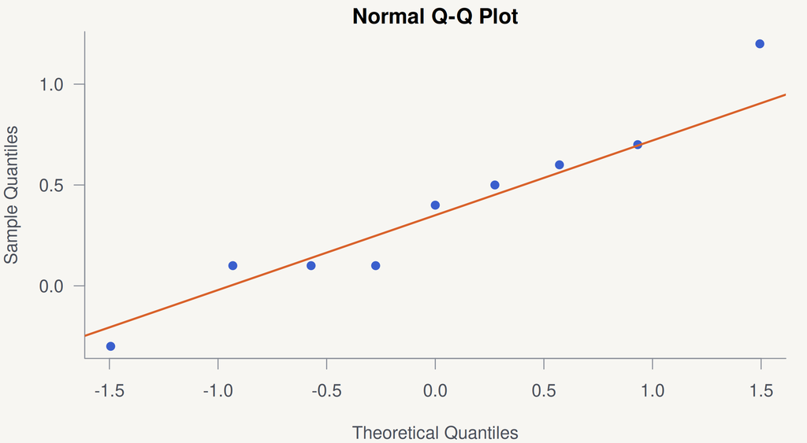

```r
B <- c(7.5, 8.1, 7.5, 7.4, 7.1, 7.5, 7.2, 7.2, 6.9)
E <- c(6.8, 6.9, 6.9, 7, 7, 7, 7.1, 7.1, 7.2)
rozdiel <- B - E
qqnorm(rozdiel, pch = 19, col = pal[3])
qqline(rozdiel, col = pal[2], lwd = 2)
```

```r
shapiro.test(rozdiel)$p.value
```

```
[1] 0.8074322
```

Pri Shapiro-Wilkovom teste je H₀ „dáta sú normálne“ → **p ≥ 0,05 je dobrá správa**. Pri párových dátach testujeme normalitu **rozdielov**.

## Párový t-test: syr B vs. pôvodný E

```r
t.test(B, E, paired = TRUE)
```

```
    Paired t-test

data:  B and E
t = 2.5868, df = 8, p-value = 0.03227
alternative hypothesis: true mean difference is not equal to 0
95 percent confidence interval:
 0.04101305 0.71454251
sample estimates:
mean difference
      0.3777778
```

Syr B je preukazne lepší ako pôvodný (p = 0,032). Wilcoxonov test dá rovnaký záver.

## Rozlišovacie testy a binomický test

| Test | vzorky | pravdepodobnosť uhádnutia |
| --- | --- | --- |
| párový, duo-trio | 2 (+ referencia) | 1/2 |
| triangel, tetráda | 3 / 4 | 1/3 |

```r
binom.test(34, 60, p = 1 / 2)$p.value                                 # párová preferencia
```

```
[1] 0.366294
```

```r
binom.test(42, 100, p = 1 / 3, alternative = "greater")$p.value       # triangel
```

```
[1] 0.04337149
```

## Kde leží 34 zo 60?

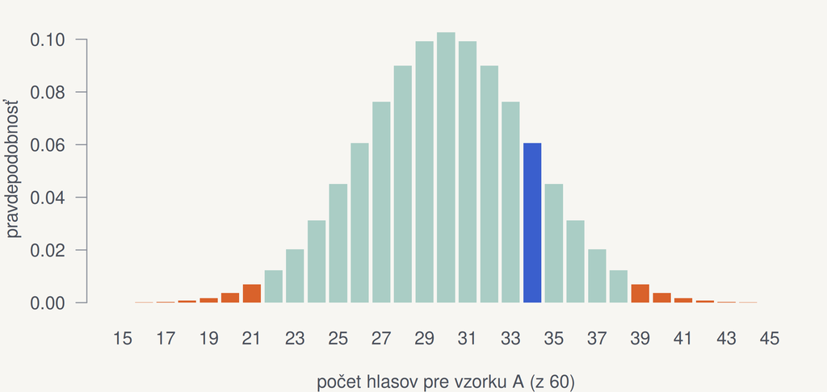

```r
k <- 15:45
barvy <- ifelse(k >= 39 | k <= 21, pal[2], ifelse(k == 34, pal[3], "#0f7b6c55"))
barplot(dbinom(k, 60, 0.5), names.arg = k, col = barvy, border = NA,
        xlab = "počet hlasov pre vzorku A (z 60)", ylab = "pravdepodobnosť")
```

Oranžová = kritická oblasť (p < 0,05). Pozorovaných 34 (modrá) je v bežnej oblasti hádania.

## χ² test a McNemarov test

**Preferencia jogurtov**

```r
chisq.test(c(25, 34, 17, 7))$p.value
```

```
[1] 0.0002581557
```

Preferencie nie sú rovnomerné.

**Stará vs. nová receptúra**

```r
rum <- matrix(c(40, 8, 24, 28), nrow = 2)
mcnemar.test(rum, correct = FALSE)$p.value
```

```
[1] 0.004677735
```

Rozhodujú len tí, čo zmenili názor (24 vs. 8).

## KVÍZ Aký test?

50 spotrebiteľov ochutnalo **starú aj novú** receptúru a pri každej povedalo, či by ju kúpili (áno/nie). Ktorým testom zistíte, či nová receptúra zmenila kúpny zámer?

**McNemarov test** – tí istí ľudia, binárna odpoveď, pred/po. χ² test nezávislosti by ignoroval párovanie.

## Viac ako dve vzorky

Pri 5 vzorkách je 10 párov → pri 10 t-testoch je šanca falošného poplachu asi **40 %**.

```r
round(1 - 0.95^c(1, 3, 6, 10), 2)
```

```
[1] 0.05 0.14 0.26 0.40
```

Najprv **jeden globálny test** (ANOVA, Kruskal-Wallis, Friedman), až potom **post-hoc** porovnania s korekciou.

## ANOVA: medzi vs. vnútri skupín

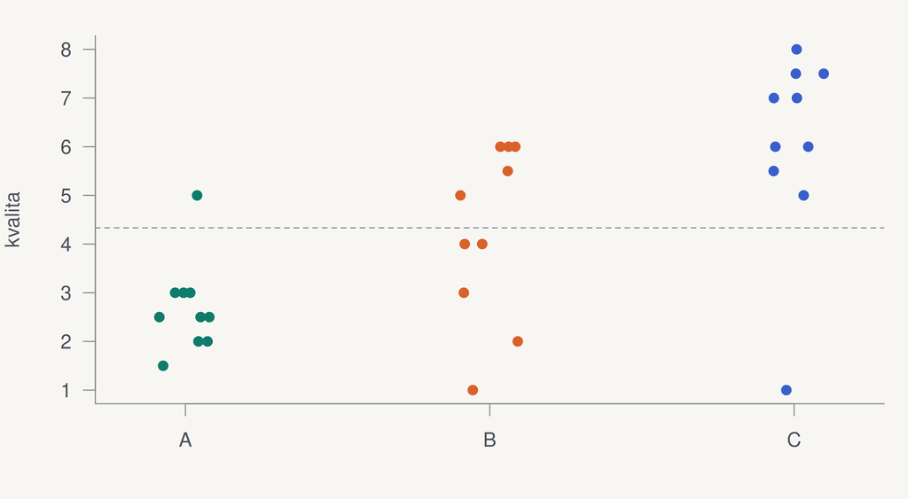

```r
cokolada <- data.frame(
  kvalita = c(1.5, 2, 2.5, 3, 2.5, 2.5, 3, 3, 2, 5,
              4, 3, 6, 5, 2, 6, 1, 6, 5.5, 4,
              6, 6, 7.5, 7, 5, 1, 8, 7, 7.5, 5.5),
  vzorka = factor(rep(c("A", "B", "C"), each = 10))
)
stripchart(kvalita ~ vzorka, data = cokolada,
           vertical = TRUE, method = "jitter",
           pch = 19, col = pal[1:3])
abline(h = mean(cokolada$kvalita), lty = 2)
```

F = variabilita medzi priemermi / variabilita vnútri skupín.

## ANOVA a Kruskal-Wallis v R

```r
summary(aov(kvalita ~ vzorka, data = cokolada))
```

```
            Df Sum Sq Mean Sq F value   Pr(>F)
vzorka       2  56.22   28.11   10.33 0.000465 ***
Residuals   27  73.45    2.72
---
Signif. codes:  0 '***' 0.001 '**' 0.01 '*' 0.05 '.' 0.1 ' ' 1
```

```r
kruskal.test(kvalita ~ vzorka, data = cokolada)$p.value
```

```
[1] 0.002500272
```

Vo vzorci je **vľavo meraná hodnota, vpravo skupina**: `kvalita ~ vzorka`. Opačný zápis dá nezmyselný výsledok.

## Post-hoc: ktoré vzorky sa líšia?

```r
TukeyHSD(aov(kvalita ~ vzorka, data = cokolada))$vzorka
```

```
    diff         lwr      upr        p adj
B-A 1.55 -0.27885263 3.378853 0.1084253376
C-A 3.35  1.52114737 5.178853 0.0002986978
C-B 1.80 -0.02885263 3.628853 0.0543663996
```

```r
pairwise.wilcox.test(cokolada$kvalita, cokolada$vzorka, p.adjust.method = "bonferroni", exact = FALSE)$p.value
```

```
            A          B
B 0.129673504         NA
C 0.009150466 0.08049856
```

## Bloky: Friedman a Durbin

- **Friedman** – každý hodnotiteľ (blok) zoradí **všetky** vzorky: `friedman.test(y ~ vzorka | hodnotitel)`
- **Durbin** – každý hodnotiteľ dostane len **časť** vzoriek podľa vyváženého plánu (BIBD)

|  | A | B | C | D | E | F | G |
| --- | --- | --- | --- | --- | --- | --- | --- |
| H1 | 2 | 3 |  | 1 |  |  |  |
| H2 |  | 3 | 1 |  | 2 |  |  |
| H3 |  |  | 2 | 1 |  | 3 |  |
| H4 |  |  |  | 1 | 2 |  | 3 |
| H5 | 3 |  |  |  | 1 | 2 |  |
| H6 |  | 3 |  |  |  | 1 | 2 |
| H7 | 3 |  | 1 |  |  |  | 2 |

7 vzoriek, každý hodnotiteľ ochutná 3, každý pár vzoriek sa stretne práve raz.

## KVÍZ Nezávislé alebo bloky?

4 kečupy hodnotilo 13 hodnotiteľov **v jednom sedení** – každý ochutnal všetky 4. Hodnotenia nie sú normálne. Ktorý test?

**Friedmanov test** – hodnotiteľ je blok (každý hodnotil všetko), dáta nie sú normálne. Kruskal-Wallis by ignoroval, že ide o tých istých ľudí.

## Zhrnutie

- Najprv **dizajn**: párové / nezávislé, dve / viac vzoriek, bloky.
- Potom **predpoklady**: normalita (graf + test).
- **Jeden globálny test**, potom post-hoc s korekciou.
- Rozlišovacie testy: binomický test s pravdepodobnosťou uhádnutia 1/2 alebo 1/3.

Teória 5a Teória 5b Teória 5c Teória 5d